# JPN Analysis

Danielle Burgess

```r
knitr::opts_chunk$set(echo=TRUE, message=FALSE, warning=FALSE, fig.show='hold', results='hold')

library(here)
library(readxl)
library(scales)
library(dplyr)
library(tidyr)
library(ggplot2)
library(stringdist)
library(lme4)
library(buildmer)
library(plotrix) #for std.error()
```

```r
# import FCT data
JPNFCT <- read_excel(path=here("tidy_data/JPNFCT.xlsx"))
# import production data
JPNProd <- read_excel(path=here("tidy_data/JPNProd.xlsx"),
                      col_types = c("text", "numeric", "text", "text",
                                    "text", "text", "text", "text",
                                    "numeric", "numeric", "numeric", "numeric"))
JPNProd$phase <- factor(JPNProd$phase,levels=c("NounProd","AffProd","NegProd"))
# import negation data
JPNNegProd <- read_excel(path=here("tidy_data/JPNNegProd.xlsx"),
                         col_types = c("text", "numeric", "text", "text",
                                       "text", "text", "text", "text",
                                       "numeric", "numeric", "numeric", "numeric",
                                       "numeric","numeric"))
JPNNegProd$condition <- as.factor(JPNNegProd$condition)

# import Questionnaire Data
JPNPostExpQ <- read_excel(path=here("tidy_data/JPNPostExpQ.xlsx"))
JPNPostExpQ <- subset(JPNPostExpQ, participant %in% JPNProd$participant)
JPNPostExpQ <- na_if(JPNPostExpQ,"NA")
JPNPostExpQ <- JPNPostExpQ %>% mutate_at(c('aoa','total','use_rate','understand_rate','media_exp_rate','social_exp_rate'), as.numeric)
```

# 1 Introduction

Is there a bias favoring preverbal negation in learning among Japanese speakers in Japan?

Participants in this study were exposed to an artificial language that had a mixture of NegV and VNeg word orders, and the ratio of these orders was manipulated depending on experimental condition. Those in the equiprobable condition saw equal amounts of both orders, whereas those in the Majority Preverbal Negation Condition saw 75% NegV order, and those in the Majority Postverbal Negation Condition saw 75% VNeg order.

Participants were trained on the artificial language in three phases. First, they were exposed to nouns, then affirmative sentences, and finally negative sentences. Each exposure phase was followed by a comprehension test, which took the form of a 2-alternative forced choice task (abbreviated FCT here), and a production test, where participants typed descriptions of images in the artificial language. This file describes analysis of accuracy in each of these tests and analysis of word order preferences. Prior to these analyses, participants with low accuracy (<75%) in the final production phase were excluded.

# 2 Accuracy

## 2.1 FCT Accuracy

In each FCT trial, participants were presented with two images and a description in the artificial language and were asked to choose which image matched the description.

The lower mean accuracy in the Negative Sentence phase of the experiment is primarily driven by errors in the first trial of that stage. After failing a trial in this phase participants saw the reminder ‘Remember that negation refers to what did NOT happen’, and overall accuracy improves if the first trial is excluded.

```r
# accuracy and standard error by phase and condition
FCT_acc <- JPNFCT %>%
  group_by(condition,phase) %>%
  summarise(mean = mean(key_resp_fct.corr),
            se = std.error(key_resp_fct.corr))

# accuracy by participant
FCT_acc_byp <- JPNFCT %>%
  group_by(participant,condition,phase) %>%
  summarise(mean = mean(key_resp_fct.corr))
FCT_acc_byp$phase <- factor(FCT_acc_byp$phase,levels=c("NounFCT","AffFCT","NegFCT"))
```

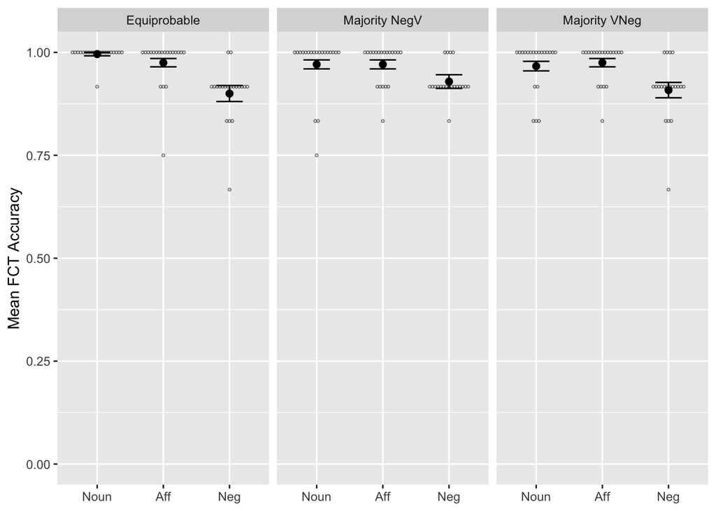

```r
Ch5FCTAcc <- ggplot(FCT_acc_byp, aes(x=phase,y=mean))+
  geom_dotplot(position="dodge", binaxis="y", stackdir="center", dotsize=0.2,fill="white",alpha=0.5)+
  geom_point(data=FCT_acc, stat="identity",size = 2)+
  geom_errorbar(data=FCT_acc, aes(ymin=mean-se,ymax=mean+se), width=0.4)+
  scale_y_continuous(limits=c(0,1))+
  scale_x_discrete(labels=c("Noun","Aff","Neg"))+
  facet_grid(~ condition)+
  labs(x = NULL, y = "Mean FCT Accuracy")
Ch5FCTAcc
ggsave(filename="Ch5FCTAcc.png",plot=Ch5FCTAcc,path=here("output"),width=6,height=4,units="in")
```

```r
FCT_overall_mean <- percent(mean(JPNFCT$key_resp_fct.corr),accuracy = 0.1)

# checking the source of low accuracy in NegFCT is first trial (FCT trial 25 in the experiment)
meanFCT_trialN <- setNames(aggregate(key_resp_fct.corr~fct_trialN,JPNFCT,mean),c("trialN","acc"))
meanFCT_trial25 <- percent(meanFCT_trialN$acc[25],accuracy=0.1)
```

Across conditions and phases, overall accuracy in the forced choice task was high (95.5%). However, to check whether there were differences in accuracy among the different input conditions, the buildmer package was used to evaluate the maximal feasible model for FCT accuracy, and to subsequently identify the model with the best fit through automated backwards stepwise elimination. This process compares the fit of a more complex model to the fit of a nested simpler model, using the Likelihood Ratio Test to determine whether the effect of a covariate is significant. The maximal effect structure for forced choice task accuracy included Phase, Condition, and their interaction as fixed effects. Backwards stepwise elimination identified the model with only a fixed effect for Phase as the best fit. Notably, including Condition as a fixed effect did not result in a better fit, indicating that the input condition was not an important factor in explaining accuracy in this task.

```r
# this code chunk is currently set not to evaluate on knit to lessen computing time
# find maximal model that will converge
max.model <- key_resp_fct.corr ~ condition * phase + (phase|participant)
fct.m <- buildmer(max.model,data=JPNFCT,family="binomial",buildmerControl=buildmerControl(direction='order', args=list(control=lmerControl(optimizer='bobyqa'))))
# maximal model that will converge:
# key_resp_fct.corr ~ condition * phase
(max.model <- formula(fct.m@model))
fct.m <- buildmer(max.model,data=JPNFCT,family="binomial",buildmerControl=list(direction='backward', args=list(control=lmerControl(optimizer='bobyqa'))))
# model with best fit via backwards stepwise comparison:
# key_resp_fct.corr ~ 1 + phase
(max.model <- formula(fct.m@model))
# the model that best fits the data includes fixed effects for phase; the fixed effects for condition did not result in a significantly better fit, indicating that the input condition was not an important factor in explaining accuracy on the forced choice task.
```

```r
# this code chunk uses the best fit model found by buildmer in the previous chunk for the report
fct.m <- glm(key_resp_fct.corr ~ 1 + phase, data=JPNFCT, family="binomial")
summary(fct.m)
```

```
##
## Call:
## glm(formula = key_resp_fct.corr ~ 1 + phase, family = "binomial",
##     data = JPNFCT)
##
## Deviance Residuals:
##     Min       1Q   Median       3Q      Max
## -2.7592   0.2120   0.2313   0.4279   0.4279
##
## Coefficients:
##              Estimate Std. Error z value Pr(>|z|)
## (Intercept)    3.6081     0.2325  15.518  < 2e-16 ***
## phaseNegFCT   -1.2635     0.2673  -4.727 2.28e-06 ***
## phaseNounFCT   0.1761     0.3435   0.513    0.608
## ---
## Signif. codes:  0 '***' 0.001 '**' 0.01 '*' 0.05 '.' 0.1 ' ' 1
##
## (Dispersion parameter for binomial family taken to be 1)
##
##     Null deviance: 797.69  on 2159  degrees of freedom
## Residual deviance: 756.34  on 2157  degrees of freedom
## AIC: 762.34
##
## Number of Fisher Scoring iterations: 6
```

## 2.2 Production Accuracy

In this file ‘strict accuracy’ refers to exact matches between the participant input and target after correcting for minor typos. ‘Loose accuracy’ counts trials where the Levenshtein distance from the target string was 4 or less (for instance, a response where only one lexical item was swapped out for another would be classified as accurate by this measure. Refer to the data preparation file to see how accuracy and Levenshtein distance was calculated in more detail.

```r
#overall accuracy
prod_overall_mean <- percent(mean(JPNProd$near_acc), accuracy=0.1)

# calculate mean accuracy (strict and loose) by participant
prod_acc_byp <- JPNProd %>%
  group_by(participant,condition,phase) %>%
  summarise(acc_strict_mean = mean(acc),
            acc_loose_mean = mean(near_acc))

# calculate mean accuracy (strict and loose) and standard errors by phase and condition
prod_acc <- JPNProd %>%
  group_by(condition,phase) %>%
  summarise(acc_strict_mean = mean(acc),
            acc_strict_se = std.error(acc),
            acc_loose_mean = mean(near_acc),
            acc_loose_se = std.error(near_acc))
```

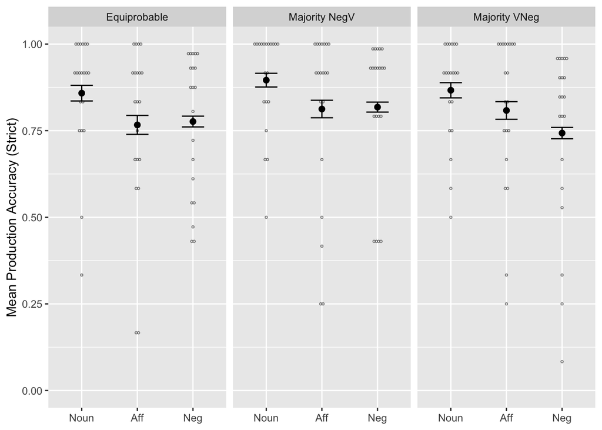

```r
Ch5ProdStrictAcc <- ggplot(prod_acc_byp, aes(y=acc_strict_mean, x=phase)) +
  geom_dotplot(position="dodge",binaxis="y", stackdir="center",dotsize=0.2,fill="white",alpha=0.5)+
  geom_point(data=prod_acc, stat="identity",size = 2)+
  geom_errorbar(data=prod_acc, aes(ymin=acc_strict_mean-acc_strict_se,ymax=acc_strict_mean+acc_strict_se),width=0.4)+
  scale_y_continuous(limits=c(0,1))+
  scale_x_discrete(labels = c('Noun','Aff','Neg'))+
  facet_grid(~condition)+
  labs(y="Mean Production Accuracy (Strict)",x=NULL)
Ch5ProdStrictAcc
ggsave(filename="Ch5ProdStrictAcc.png",plot=Ch5ProdStrictAcc ,path=here("output"),width=6,height=4,units="in")
```

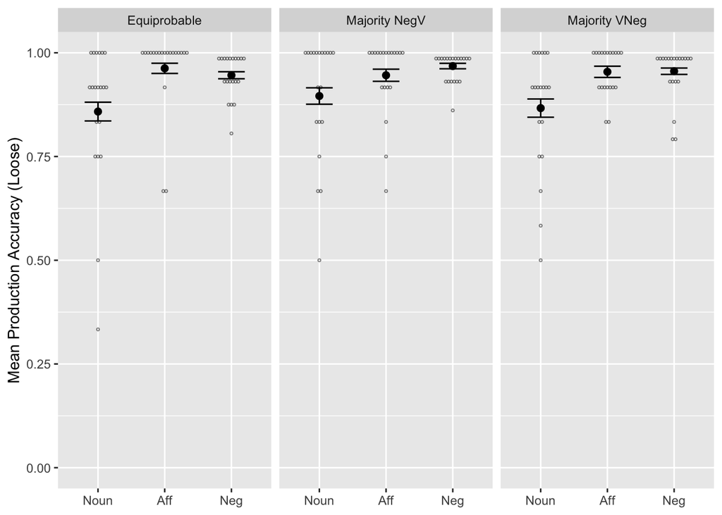

```r
Ch5ProdLooseAcc <- ggplot(prod_acc_byp, aes(y=acc_loose_mean, x=phase)) +
  geom_dotplot(position="dodge",binaxis="y", stackdir="center",dotsize=0.2,fill="white",alpha=0.5)+
  geom_point(data=prod_acc, stat="identity",size = 2)+
  geom_errorbar(data=prod_acc, aes(ymin=acc_loose_mean-acc_loose_se,ymax=acc_loose_mean+acc_loose_se),width=0.4)+
  scale_y_continuous(limits=c(0,1))+
  scale_x_discrete(labels = c('Noun','Aff','Neg'))+
  facet_grid(~condition)+
  labs(y="Mean Production Accuracy (Loose)",x=NULL)
Ch5ProdLooseAcc
ggsave(filename="Ch5ProdLooseAcc.png",plot=Ch5ProdLooseAcc ,path=here("output"),width=6,height=4,units="in")
```

Across conditions and phases, overall accuracy in the production task was high (93.9%). Backwards stepwise elimination with the buildmer package was again used to check whether there were differences in accuracy among the different input conditions. This identified a model with only a fixed effect for Phase as the best fit. Notably, including Condition as a fixed effect did not result in a better fit, indicating that the input condition was not an important factor in explaining accuracy in this task.

```r
# this code chunk is currently set not to evaluate on knit to lessen computing time
# find maximal model that will converge
max.model <- near_acc ~ condition * phase + (phase|participant)
prod.m <- buildmer(max.model,data=JPNProd,family="binomial",buildmerControl=buildmerControl(direction='order', args=list(control=lmerControl(optimizer='bobyqa'))))
# maximal model that will converge:
# near_acc ~ 1 + phase * condition
(max.model <- formula(prod.m@model))
prod.m <- buildmer(max.model,data=JPNProd,family="binomial",buildmerControl=list(direction='backward', args=list(control=lmerControl(optimizer='bobyqa'))))
# model with best fit via backwards stepwise comparison:
# near_acc ~ 1 + phase
(max.model <- formula(prod.m@model))
```

## 2.3 Excluded Critical Trials

```r
cr_excluded  <- sum(is.na(JPNNegProd$NegVorder))
cr_total <- length(JPNNegProd$NegVorder)
cr_percent <- percent(cr_excluded/cr_total, accuracy=0.1)
```

The total number of excluded critical (negative sentence) production trials across the experiment is 90 (6.2% out of 1440 trials).

# 3 Word Order

This graph shows the proportion of NegV order in each condition.

```r
# calculate proportion NegV order by participant
NegV_byp <- JPNNegProd %>%
  drop_na(NegVorder) %>%
  group_by(condition,participant,phase) %>%
  summarise(mean_negV = mean(NegVorder))

# summary statistics by condition and phase
NegV_summary <- NegV_byp %>%
  group_by(condition,phase) %>%
  summarise(mean = mean(mean_negV),
            se = std.error(mean_negV))

NegV_summary$input_prop <- case_when(
  NegV_summary$condition=="Majority VNeg" ~ 0.25,
  NegV_summary$condition=="Majority NegV" ~ 0.75,
  NegV_summary$condition=="Equiprobable" ~ 0.50)
```

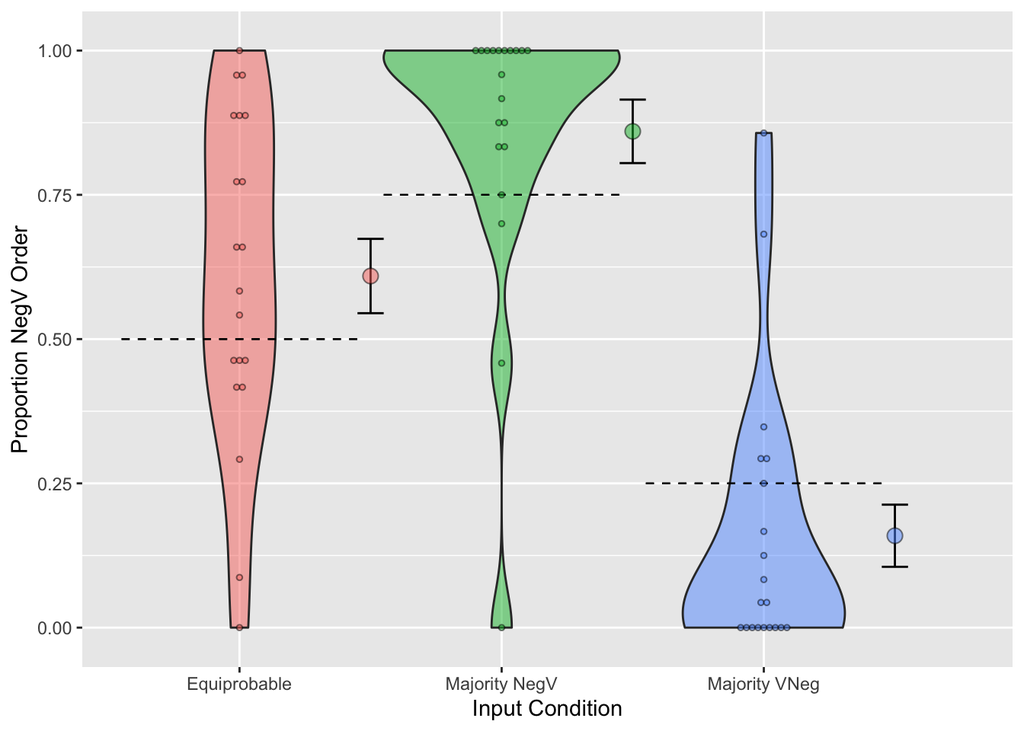

```r
Ch5NegVPlot <- ggplot(data=NegV_byp, aes(x=condition, fill=condition))+
  geom_violin(position=position_dodge(),aes(y=mean_negV),show.legend = FALSE, alpha=0.5)+
  geom_errorbar(data=NegV_summary, aes(ymin=input_prop,ymax=input_prop),linetype="dashed", size=.4)+
  geom_errorbar(data=NegV_summary, position=position_nudge(0.5),aes(y=mean, ymin=mean-se,ymax=mean+se),width=0.1)+
  geom_dotplot(position="dodge", aes(y=mean_negV), dotsize=0.3, binaxis="y", stackdir="center", alpha=0.5,show.legend = FALSE)+
  geom_dotplot(data=NegV_summary, aes(y=mean), dotsize=0.8, alpha=0.5, binaxis="y", stackdir="center", position_nudge(x=0.5),show.legend = FALSE)+
  labs(x = "Input Condition", y = "Proportion NegV Order")
Ch5NegVPlot

ggsave(filename="Ch5NegVPlot.png",plot=Ch5NegVPlot,path=here("output"),width=6,height=4,units="in")
```

## 3.1 NegV Order Use

In the following chunk, we use mixed effects logistic regression to answer the following questions:

1. Are participants in the Equiprobable condition producing NegV order significantly greater than chance?
- A model including NegV Order as the binary dependent variable, Condition as a fixed effect, and random intercepts for Participants, with the Equiprobable condition as the reference level, showed no significant intercept, indicating that the choice of preverbal negation order in the Equiprobable condition was not significantly different from chance.
2. Are participants in the Majority NegV condition more likely to boost the majority order (NegV) than participants in the Majority VNeg condition?
- A model including Majority Order as the binary dependent variable, Condition as a fixed effect, and random intercepts for Participants, with the Majority NegV condition as the reference level, showed no significant difference between the amount of boosting in the Majority NegV condition and the Majority VNeg Condition.

Thus, the Japanese data are not consistent with a bias favoring Preverbal Negation (nor a bias favoring Postverbal Negation).

```r
#  1. If the intercept is significant and positive then odds of participants producing NegV order was significantly greater than chance

model.equi <- glmer(NegVorder~condition+(1|participant),data=JPNNegProd,family="binomial")
summary(model.equi)

# 2. Compare chance of majority word order use in NegV condition against VNeg condition
JPNNegProd$condition <- relevel(JPNNegProd$condition, "Majority NegV")
model.majority <- glmer(majorityOrder~condition+(1|participant),data=JPNNegProd,family="binomial")
summary(model.majority)
```

```
## Generalized linear mixed model fit by maximum likelihood (Laplace
##   Approximation) [glmerMod]
##  Family: binomial  ( logit )
## Formula: NegVorder ~ condition + (1 | participant)
##    Data: JPNNegProd
##
##      AIC      BIC   logLik deviance df.resid
##   1013.1   1033.9   -502.6   1005.1     1346
##
## Scaled residuals:
##     Min      1Q  Median      3Q     Max
## -4.8221 -0.2305  0.1046  0.3612  4.7392
##
## Random effects:
##  Groups      Name        Variance Std.Dev.
##  participant (Intercept) 5.064    2.25
## Number of obs: 1350, groups:  participant, 60
##
## Fixed effects:
##                        Estimate Std. Error z value Pr(>|z|)
## (Intercept)              0.6524     0.5269   1.238  0.21569
## conditionMajority NegV   2.5467     0.8152   3.124  0.00178 **
## conditionMajority VNeg  -3.6475     0.8114  -4.495 6.94e-06 ***
## ---
## Signif. codes:  0 '***' 0.001 '**' 0.01 '*' 0.05 '.' 0.1 ' ' 1
##
## Correlation of Fixed Effects:
##             (Intr) cndMNV
## cndtnMjrNgV -0.641
## cndtnMjrtVN -0.655  0.365
## Generalized linear mixed model fit by maximum likelihood (Laplace
##   Approximation) [glmerMod]
##  Family: binomial  ( logit )
## Formula: majorityOrder ~ condition + (1 | participant)
##    Data: JPNNegProd
##
##      AIC      BIC   logLik deviance df.resid
##   1013.1   1033.9   -502.6   1005.1     1346
##
## Scaled residuals:
##     Min      1Q  Median      3Q     Max
## -4.8221  0.1046  0.1106  0.3949  2.8377
##
## Random effects:
##  Groups      Name        Variance Std.Dev.
##  participant (Intercept) 5.064    2.25
## Number of obs: 1350, groups:  participant, 60
##
## Fixed effects:
##                        Estimate Std. Error z value Pr(>|z|)
## (Intercept)              3.1991     0.6258   5.112 3.18e-07 ***
## conditionEquiprobable   -2.5467     0.8151  -3.124  0.00178 **
## conditionMajority VNeg  -0.2040     0.8341  -0.245  0.80678
## ---
## Signif. codes:  0 '***' 0.001 '**' 0.01 '*' 0.05 '.' 0.1 ' ' 1
##
## Correlation of Fixed Effects:
##             (Intr) cndtnE
## cndtnEqprbb -0.763
## cndtnMjrtVN -0.681  0.523
```

# 4 Language Background

```r
JPNLangExp <- JPNPostExpQ %>%
  group_by(language) %>%
  summarise(count = n(),
            mean_aoa = mean(aoa, na.rm=TRUE),
            mean_total = mean(total, na.rm=TRUE),
            mean_use = mean(use_rate, na.rm=TRUE),
            mean_understand = mean(understand_rate, na.rm=TRUE),
            mean_media_exp = mean(media_exp_rate, na.rm=TRUE),
            mean_social_exp = mean(social_exp_rate, na.rm=TRUE))

# participants were asked to rate their comfort using and understanding each language they listed in the survey
# these ratings were highly correlated
cor.test(JPNPostExpQ$use_rate,JPNPostExpQ$understand_rate)
cor.test(JPNPostExpQ$use_rate,JPNPostExpQ$media_exp_rate)
cor.test(JPNPostExpQ$use_rate,JPNPostExpQ$social_exp_rate)
```

```
##
##  Pearson's product-moment correlation
##
## data:  JPNPostExpQ$use_rate and JPNPostExpQ$understand_rate
## t = 23.303, df = 134, p-value < 2.2e-16
## alternative hypothesis: true correlation is not equal to 0
## 95 percent confidence interval:
##  0.8563524 0.9245377
## sample estimates:
##       cor
## 0.8955847
##
##
##  Pearson's product-moment correlation
##
## data:  JPNPostExpQ$use_rate and JPNPostExpQ$media_exp_rate
## t = 11.272, df = 132, p-value < 2.2e-16
## alternative hypothesis: true correlation is not equal to 0
## 95 percent confidence interval:
##  0.6022867 0.7775773
## sample estimates:
##       cor
## 0.7003416
##
##
##  Pearson's product-moment correlation
##
## data:  JPNPostExpQ$use_rate and JPNPostExpQ$social_exp_rate
## t = 12.279, df = 133, p-value < 2.2e-16
## alternative hypothesis: true correlation is not equal to 0
## 95 percent confidence interval:
##  0.6386120 0.7994233
## sample estimates:
##       cor
## 0.7289201
```

```r
#treat ratings as ordered factors
JPNPostExpQ$use_rate <- factor(JPNPostExpQ$use_rate,ordered=TRUE)
JPNPostExpQ$understand_rate <- factor(JPNPostExpQ$understand_rate,ordered=TRUE)
JPNPostExpQ$media_exp_rate <- factor(JPNPostExpQ$media_exp_rate,ordered=TRUE)
JPNPostExpQ$social_exp_rate <- factor(JPNPostExpQ$social_exp_rate,ordered=TRUE)
```

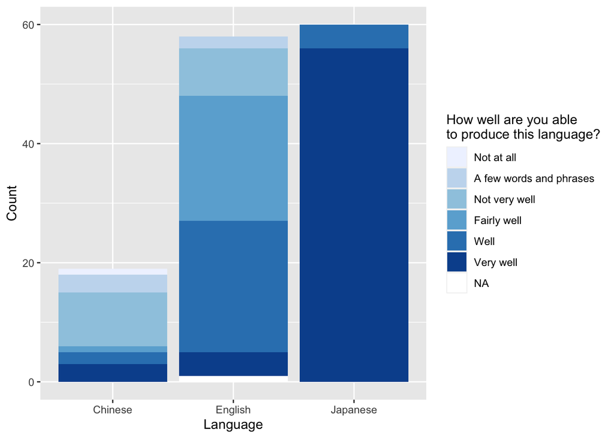

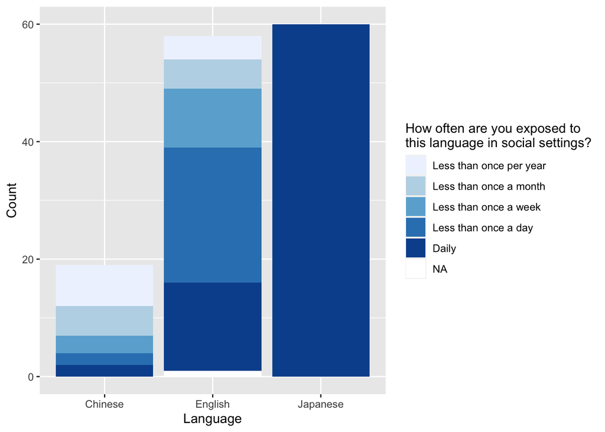

```r
fluency_labels <- c("Not at all","A few words and phrases","Not very well","Fairly well","Well","Very well")
exposure_labels <-c("Less than once per year","Less than once a month","Less than once a week","Less than once a day","Daily")

JPNLangUsePlot <- ggplot(JPNPostExpQ, aes(x=language,fill=use_rate)) +
  geom_bar() +
  scale_fill_brewer(na.value="white",name="How well are you able \nto produce this language?",labels=fluency_labels)+
  labs(x="Language",y="Count")+
  scale_x_discrete(labels = c('Chinese','English','Japanese'))
JPNLangUsePlot
ggsave(filename="Ch5LangUsePlot.png",plot=JPNLangUsePlot,path=here("output"),width=6,height=4,units="in")

JPNLangExpPlot <- ggplot(JPNPostExpQ, aes(x=language,fill=social_exp_rate)) +
  geom_bar() +
  scale_fill_brewer(na.value="white",name="How often are you exposed to \nthis language in social settings?",labels=exposure_labels)+
  labs(x="Language",y="Count")+
  scale_x_discrete(labels = c('Chinese','English','Japanese'))
JPNLangExpPlot
```

```r
# combine with condition
JPNPostExpQ <- merge(JPNPostExpQ, unique(JPNNegProd[,c("participant","condition")]), by="participant")
```

```r
eng_use_rate <- JPNPostExpQ %>% filter(language=="english")
EngUseNegProd <- merge(JPNNegProd, eng_use_rate[,c("participant","use_rate")], by="participant")

EngUseNegProd$use_rate <- case_when(
  EngUseNegProd$use_rate < 4 ~ "lower",
  EngUseNegProd$use_rate >= 4 ~ "higher")
EngUseNegProd$use_rate <- factor(EngUseNegProd$use_rate)

EngUseNegProd$condition <- relevel(EngUseNegProd$condition, "Majority NegV")
eng.m <- glmer(NegVorder~use_rate*condition+(1|participant),data=EngUseNegProd,family="binomial")
summary(eng.m)
```

```
## Generalized linear mixed model fit by maximum likelihood (Laplace
##   Approximation) [glmerMod]
##  Family: binomial  ( logit )
## Formula: NegVorder ~ use_rate * condition + (1 | participant)
##    Data: EngUseNegProd
##
##      AIC      BIC   logLik deviance df.resid
##    955.4    991.6   -470.7    941.4     1281
##
## Scaled residuals:
##     Min      1Q  Median      3Q     Max
## -5.3538 -0.2231  0.0816  0.3602  4.8847
##
## Random effects:
##  Groups      Name        Variance Std.Dev.
##  participant (Intercept) 4.741    2.177
## Number of obs: 1288, groups:  participant, 57
##
## Fixed effects:
##                                      Estimate Std. Error z value Pr(>|z|)
## (Intercept)                            4.2607     0.9033   4.717 2.39e-06 ***
## use_ratelower                         -1.8641     1.2080  -1.543   0.1228
## conditionEquiprobable                 -3.0791     1.2978  -2.373   0.0177 *
## conditionMajority VNeg                -7.5969     1.2575  -6.041 1.53e-09 ***
## use_ratelower:conditionEquiprobable    1.1501     1.6537   0.695   0.4868
## use_ratelower:conditionMajority VNeg   2.9422     1.6691   1.763   0.0779 .
## ---
## Signif. codes:  0 '***' 0.001 '**' 0.01 '*' 0.05 '.' 0.1 ' ' 1
##
## Correlation of Fixed Effects:
##             (Intr) us_rtl cndtnE cndMVN us_r:E
## use_ratelwr -0.713
## cndtnEqprbb -0.692  0.495
## cndtnMjrtVN -0.758  0.526  0.522
## us_rtlwr:cE  0.519 -0.730 -0.769 -0.382
## us_rtlw:MVN  0.516 -0.724 -0.358 -0.689  0.528
```

Backwards stepwise comparison with buildmer shows that including self-reported ratings of ability to produce English does not improve the fit of the model.

```r
# this code chunk is currently set not to evaluate on knit to lessen computing time
# find maximal model that will converge
max.model <- NegVorder~use_rate*condition+(1|participant)
compare.m <- buildmer(max.model,data=EngUseNegProd,family="binomial",buildmerControl=buildmerControl(direction='order', args=list(control=lmerControl(optimizer='bobyqa'))))
# maximal model that will converge:
# NegVorder ~ 1 + condition + use_rate + condition:use_rate + (1 | participant)
(max.model <- formula(compare.m@model))
compare.m <- buildmer(max.model,data=EngUseNegProd,family="binomial",buildmerControl=list(direction='backward', args=list(control=lmerControl(optimizer='bobyqa'))))
# model with best fit via backwards stepwise comparison:
# NegVorder ~ 1 + condition + (1 | participant)
(max.model <- formula(compare.m@model))
```

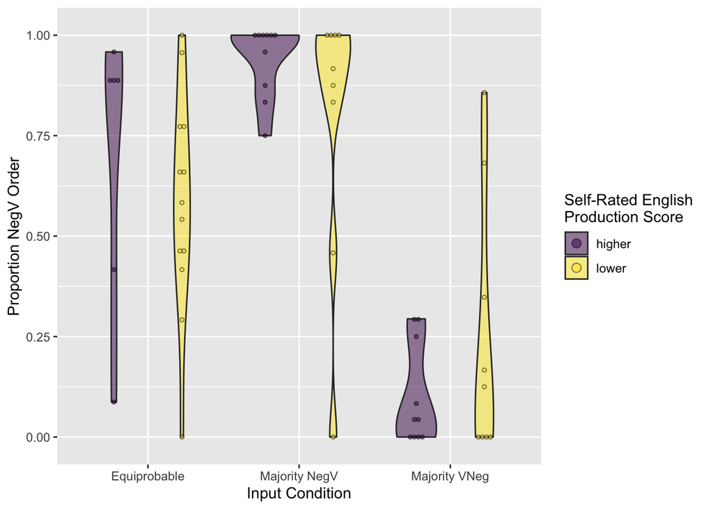

```r
EngUseNegProd$condition <- relevel(EngUseNegProd$condition, "Equiprobable")
EngUse_NegV_participant <- EngUseNegProd %>%
  group_by(condition,participant,use_rate) %>%
  summarise(mean_negV = mean(NegVorder, na.rm=TRUE))
EngUse_NegV_participant$condition <- factor(EngUse_NegV_participant$condition)
EngUse_NegV_participant$use_rate <- factor(EngUse_NegV_participant$use_rate,ordered=TRUE)

EngUse_NegV <- ggplot(data=EngUse_NegV_participant, aes(x=condition,fill=use_rate))+
  geom_violin(position=position_dodge(),aes(fill=use_rate,y=mean_negV),alpha=0.5)+
  geom_dotplot(position="dodge", aes(y=mean_negV), dotsize=0.3, binaxis="y", stackdir="center", alpha=0.5)+
  labs(x = "Input Condition", y = "Proportion NegV Order",fill="Self-Rated English \nProduction Score") +
  guides(fill = guide_legend(override.aes = list(shape = NA)))
EngUse_NegV
```